# HW2

This author section should be left blank empty for anonymous grading

Due 2024-02-06

## Instruction:

Once you have completed your answer, please submit both the knitted .html file and the .rmd file together.

### Question 1: Write your code in the code chunk and your text answer after the code chunk.

```r
fruitfly <- read.csv("datasets/fruitfly.csv")
summary(fruitfly)
```

```
##        No          type      lifespan         thorax          sleep
##  Min.   : 1   Min.   :1   Min.   :16.00   Min.   :0.640   Min.   : 1.00
##  1st Qu.: 7   1st Qu.:2   1st Qu.:46.00   1st Qu.:0.760   1st Qu.:13.00
##  Median :13   Median :3   Median :58.00   Median :0.840   Median :20.00
##  Mean   :13   Mean   :3   Mean   :57.44   Mean   :0.821   Mean   :23.46
##  3rd Qu.:19   3rd Qu.:4   3rd Qu.:70.00   3rd Qu.:0.880   3rd Qu.:29.00
##  Max.   :25   Max.   :5   Max.   :97.00   Max.   :0.940   Max.   :83.00
```

The mean lifespan of all of the fruitflies is 57.44 days. The standard deviation of lifespan is 17.5638926 days.

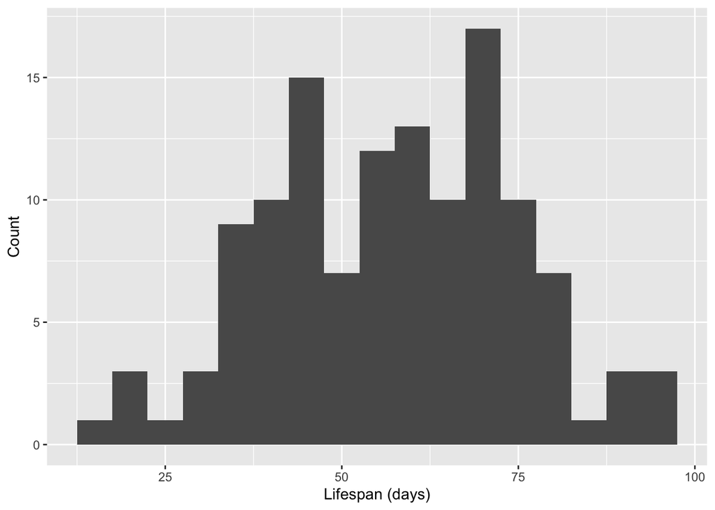

```r
ggplot(fruitfly) +
  geom_histogram(binwidth = 5, aes(x = lifespan)) +
  ylab("Count") +
  xlab("Lifespan (days)")
```

The distribution of the overall lifespan looks to be relatively normal.

### Question 2: Write your code in the code chunk and your text answer after the code chunk.

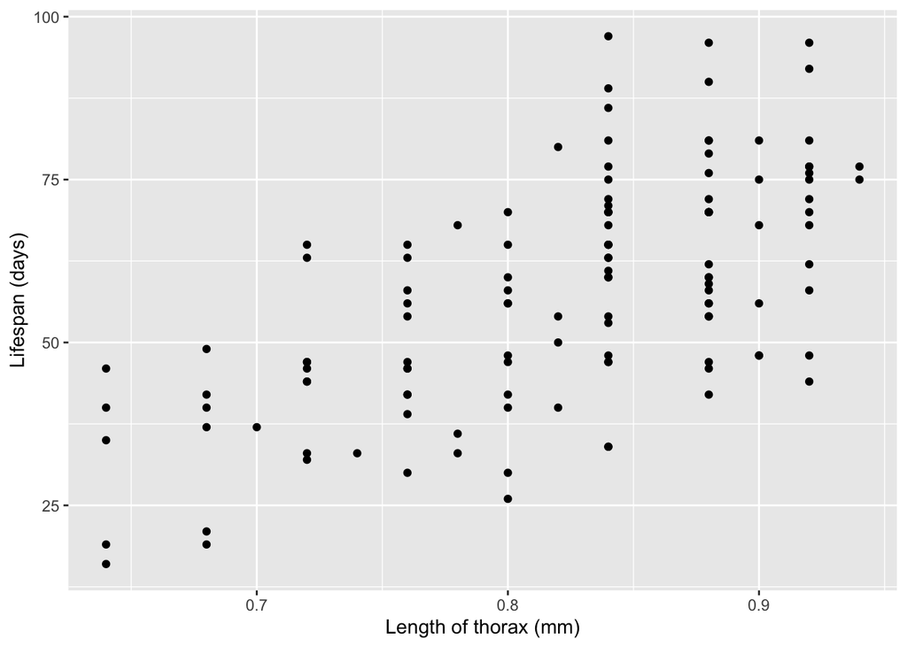

```r
ggplot(fruitfly) +
  geom_point(aes(x = thorax, y = lifespan)) +
  ylab("Lifespan (days)") +
  xlab("Length of thorax (mm)")
```

```r
cor <- cor(fruitfly$thorax, fruitfly$lifespan)
```

It looks like there is a linear relationship. The correlation coefficient is 0.6364835, which indicates that there is a moderate positive relationship between these two variables.

### Question 3: Write your code in the code chunk and your text answer after the code chunk.

```r
y <- fruitfly$lifespan
x <- fruitfly$thorax
lm <- lm(y ~ x)
summary(lm)
```

```
##
## Call:
## lm(formula = y ~ x)
##
## Residuals:
##     Min      1Q  Median      3Q     Max
## -28.415  -9.961   1.132   9.265  36.812
##
## Coefficients:
##             Estimate Std. Error t value Pr(>|t|)
## (Intercept)   -61.05      13.00  -4.695  7.0e-06 ***
## x             144.33      15.77   9.152  1.5e-15 ***
## ---
## Signif. codes:  0 '***' 0.001 '**' 0.01 '*' 0.05 '.' 0.1 ' ' 1
##
## Residual standard error: 13.6 on 123 degrees of freedom
## Multiple R-squared:  0.4051, Adjusted R-squared:  0.4003
## F-statistic: 83.76 on 1 and 123 DF,  p-value: 1.497e-15
```

The slope of the model is 144.333101. This slope implies that for every 1 additional mm in length of a fly’s thorax, the lifespan of that fly will be 144.333101 days longer. Of course, there are no flies in the dataset with a thorax of even 1mm long, so in reality we can only assume this slope to roughly apply to flies that have thorax lengths that are in the dataset (thoraxes between roughly 0.7mm to 0.9mm).

### Question 4: Write your code in the code chunk and your text answer after the code chunk.

H0: slope ($\beta_1$) == 0 Ha: slope ($\beta_1$) != 0

```r
slope_standard_error <- summary(lm)$coefficients[2, 2]

t_statistic <- (lm$coefficients[2] - 0) / slope_standard_error

p_value <- 2 * pt(t_statistic, length(fruitfly$lifespan) - 2, lower.tail = F)
```

The p-value is 1.4967613^{-15}, which is less than 0.05, so we can reject the null hypothesis, meaning that the slope is NOT zero, and the linear relationship between *lifespan* and *thorax* is **significant**.

### Question 5: Write your code in the code chunk and your text answer after the code chunk.

```r
# Using the formula:
critical_value <- qt(0.05, length(fruitfly$lifespan) - 2, lower.tail = F) # Find the critical value for 95% CI

upper <- lm$coefficients[2] + critical_value * slope_standard_error
lower <- lm$coefficients[2] - critical_value * slope_standard_error

# Using the R function `confint()`
confidence_interval <- confint(lm, level = 0.9)
```

Using the formula, the 90% confidence interval is [118.1961605, 170.4700416].

Using the function, the 90% confidence interval is [118.1961605, 170.4700416]

### Question 6: Write your code in the code chunk and your text answer after the code chunk.

```r
# Find individual fruitfly lifespan with thorax value 0.8 mm
individual <- predict(lm, newdata = data.frame(x = 0.8), se.fit = TRUE, interval = "prediction")

# Find average fruitfly lifespan with thorax value 0.8 mm
confidence <- predict(lm, newdata = data.frame(x = 0.8), se.fit = TRUE, interval = "confidence")
```

The predicted value of lifespan is 54.4147782 days.

The prediction interval for an individual fruitfly’s lifespan with a 0.8mm thorax is [27.3754167 days, 81.4541397 days].

The confidence interval for the average fruitfly’s lifespan with a 0.8mm thorax is [51.9193208 days, 56.9102356 days].

### Question 7: Write your code in the code chunk and your text answer after the code chunk.

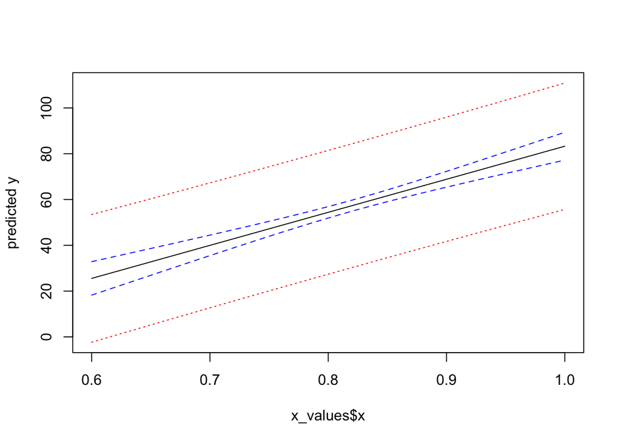

```r
x_values <- data.frame(x = seq(0.6,1,0.01)) # seq() generates numbers from 10 to 90 by increments of 5

confidence_intervals <- predict(lm, newdata = x_values, interval = "confidence")
prediction_intervals <- predict(lm, newdata = x_values, interval = "prediction")

matplot(
  x_values$x,
  cbind(confidence_intervals, prediction_intervals[,-1]), # in order to avoid having two `fit` columns, we will extract the `fit` column from prediction_intervals
  lty = c(1,2,2,3,3),
  type = "l",
  col = c("black", "blue", "blue", "red", "red"),
  ylab = "predicted y"
) # lty = line type, type = line, ylab = y axis label
```